# Assisting Development Policy-Making Process in Mexico

#MODEL FOR DEVELOPMENT POLICY

```r
#The three components in the model and their average values
#1. Material conditions

material = (income * 0.45 + jobs * 0.45 + housing * 0.1)

  #1.1. Income: Household disposable income per capita (in real USD PPP) - 0 to 10
  #1.2. Jobs: Employment and Unemployment Rate - 0 to 10
  #1.3. Housing: Number of rooms per person (ratio)

#2. Quality of Life

quality = (health * 0.35 + education * 0.3 + environment * 0.25 + safety * 0.05 + civic_engagement * 0.05)

  #2.1. Health: Life expectancy at birth (years) and Age-adjusted mortality rate (per 1 000 people) - 0 to 10
  #2.2. Education: Share of the labour force with at least secondary education - 0 to 10
  #2.3. Environment: Estimated average exposure to air pollution in PM2.5 (μg/m³), based on satellite imagery data-0 to 10
  #2.4. Safety: Homicide rate (per 100 000 people) - 0 to 10
  #2.5. Civic Engagement: Voter turnout - 0 to 10


  #3. Subjective Well-Being

subjectivity = (community * 0.3 + life_satisfaction * 0.7)

  #3.1. Community: Percentage of people who have friends or relatives to rely on in case of need
  #3.2. Life satisfaction: Average self-evaluation of life satisfaction on a scale from 0 to 10

#I will assign weights to each component to show their importance in the development model and score.
#0.4 (40%) for material conditions, 0.40 (40%) for quality conditions, 0.2 (20%) for subjectivity conditions

#Final model for our analysis
development_model = material * 0.4 + quality * 0.4 + subjectivity * 0.2
```

#Adding the Model

```r
#Adding updated model to the data set for our analysis
mexico_data <- mexico_data %>%
  mutate(
       development_model = (material * 0.4) +
                    (quality * 0.4) +
                    (subjectivity * 0.2)
  )
```

#Ranking the regions based on our new model

```r
#Regions with the highest development scores
highest_dev_scores <- mexico_data %>%
  arrange(desc(development_model)) %>%
  select(Provinces, development_model) %>%
  top_n(5)
#Regions with the lowest development scores
lowest_dev_scores <- mexico_data %>%
  arrange(development_model) %>%
  select(Provinces, development_model) %>%
  top_n(-5)
```

#All Regions

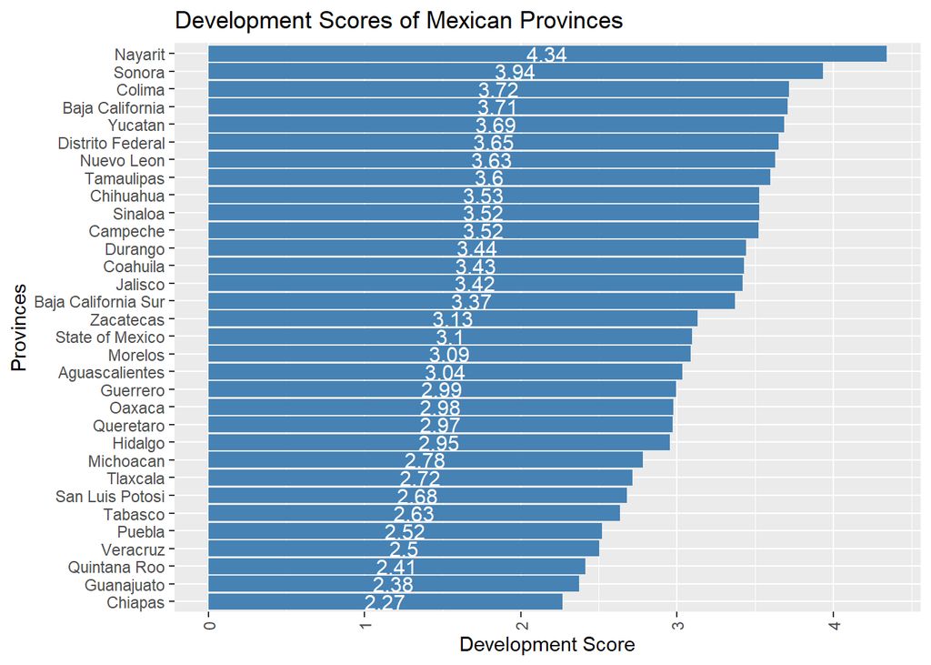

```r
#All regions sorted by development score
all_dev_scores <- mexico_data %>%
  arrange(desc(development_model)) %>%
  select(Provinces, development_model)

#Creating the bar plot for all regions
ggplot(all_dev_scores, aes(x = reorder(Provinces, development_model), y = development_model)) +
  geom_bar(stat = "identity", fill = "steelblue") +
  geom_text(aes(label = round(development_model, 2)), position = position_stack(vjust = 0.5), color = "white", size = 4) +
  theme(axis.text.x = element_text(angle = 90, vjust = 0.5, hjust = 1)) +
  labs(title = "Development Scores of Mexican Provinces",
       x = "Provinces",
       y = "Development Score") +
  coord_flip()
```

#Top and Bottom 5 Scores

```r
#Top 5 Regions with the Highest Development scores
print(highest_dev_scores) #Our model demonstrates that the top 5 regions are: Nayarit, Sonora, Colima, Baja California, Yucatan
```

```
## # A tibble: 5 × 2
##   Provinces       development_model
##   <chr>                       <dbl>
## 1 Nayarit                      4.34
## 2 Sonora                       3.94
## 3 Colima                       3.72
## 4 Baja California              3.71
## 5 Yucatan                      3.69
```

```r
#Bottom 5 Regions with the Lowest Development scores
print(lowest_dev_scores) #Our model demonstrates that the 5 regions with the lowest scores are: Chiapas, Guanajuato, Quintana Roo, Veracruz, Puebla
```

```
## # A tibble: 5 × 2
##   Provinces    development_model
##   <chr>                    <dbl>
## 1 Chiapas                   2.27
## 2 Guanajuato                2.38
## 3 Quintana Roo              2.41
## 4 Veracruz                  2.50
## 5 Puebla                    2.52
```

#Visualizing the development ranking

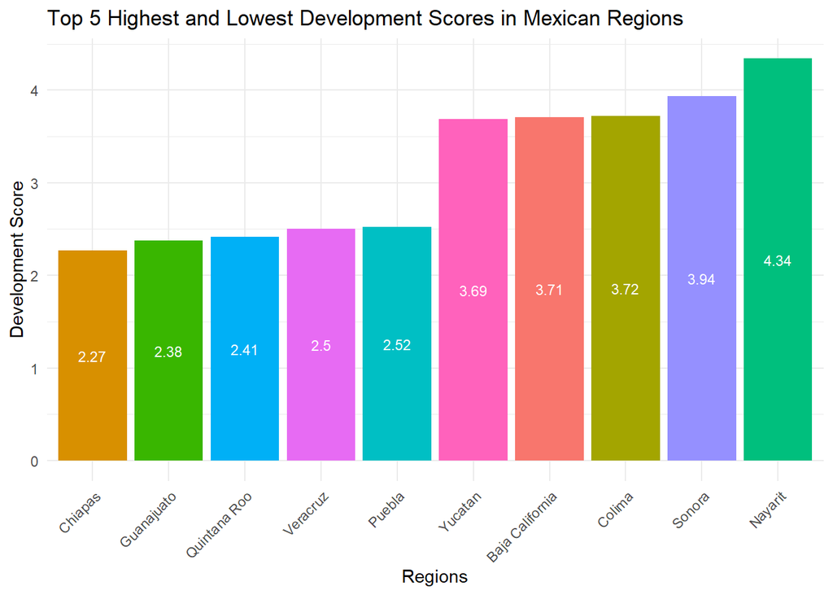

```r
#Combining the highest and lowest development scores
high_low_regions <- rbind(highest_dev_scores, lowest_dev_scores)

#Creating a bar chart
ggplot(high_low_regions, aes(x = reorder(Provinces, development_model), y = development_model, fill = Provinces)) +
  geom_bar(stat = "identity") +
  geom_text(aes(label = round(development_model, 2)), position = position_stack(vjust = 0.5), color = "white", size = 3) +
  theme_minimal() +
  theme(axis.text.x = element_text(angle = 45, hjust = 1)) +
  labs(x = "Regions", y = "Development Score", title = "Top 5 Highest and Lowest Development Scores in Mexican Regions") +
  guides(fill = FALSE)
```

#6. PRINCIPAL COMPONENT ANALYSIS (PCA)

#Principal Component Analysis (PCA) is a powerful and widely used technique to reduce dimensionality and create data visualizations. It allows us to visualize the relationships between observations (provinces) in a lower-dimensional space while retaining as much of the original information as possible. It is also a great technique before applying the k-means clustering.

#First, we need to choose the numeric columns and assign them as a new matrix.

```r
# Selecting numeric columns and casting to matrix
mexico_mat  <- mexico_data  %>%
  select(3:13) %>%
  as.matrix()

# Checking a few lines of the numeric columns
head(mexico_mat)
```

```
##      Education     Jobs   Income   Safety   Health Environment Civic engagement
## [1,]  1.700443 5.942970 0.176240 8.423913 3.017920    5.621891         1.513648
## [2,]  1.629428 6.785714 0.437541 0.002240 2.430376    4.328358         0.009974
## [3,]  2.203604 7.142387 0.338202 7.635870 2.950353    7.064677         1.357997
## [4,]  1.309072 6.836815 0.010000 8.097826 2.413337    4.726368         4.432664
## [5,]  1.413771 5.934971 0.211325 8.043478 2.618684    5.771144         3.158132
## [6,]  1.758074 7.831357 0.270276 0.001470 2.239718    6.368159         2.188134
##      Accessiblity to services  Housing Community Life satisfaction
## [1,]                 4.155700 1.292135  1.081081          3.076923
## [2,]                 4.922864 1.235955  5.225225          7.692308
## [3,]                 4.542863 0.505618  0.180180          3.076923
## [4,]                 3.629144 0.010000  6.216216          5.000000
## [5,]                 4.219586 1.685393  0.009986          6.538462
## [6,]                 4.062717 0.842697  2.657658          6.153846
```

#PCA

```r
#Applying Principal Component Analysis (PCA)
mexico_pca  <- PCA(mexico_mat, scale.unit = TRUE) #Performing PCA with the FactoMineR package and scaling units to avoid large variances
```

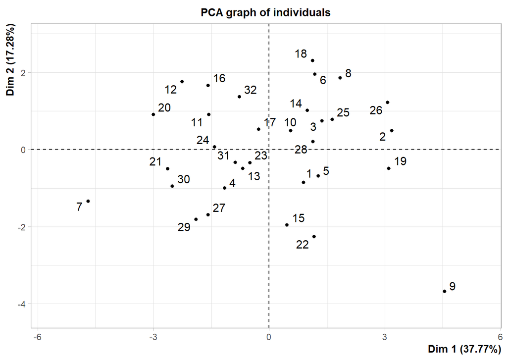

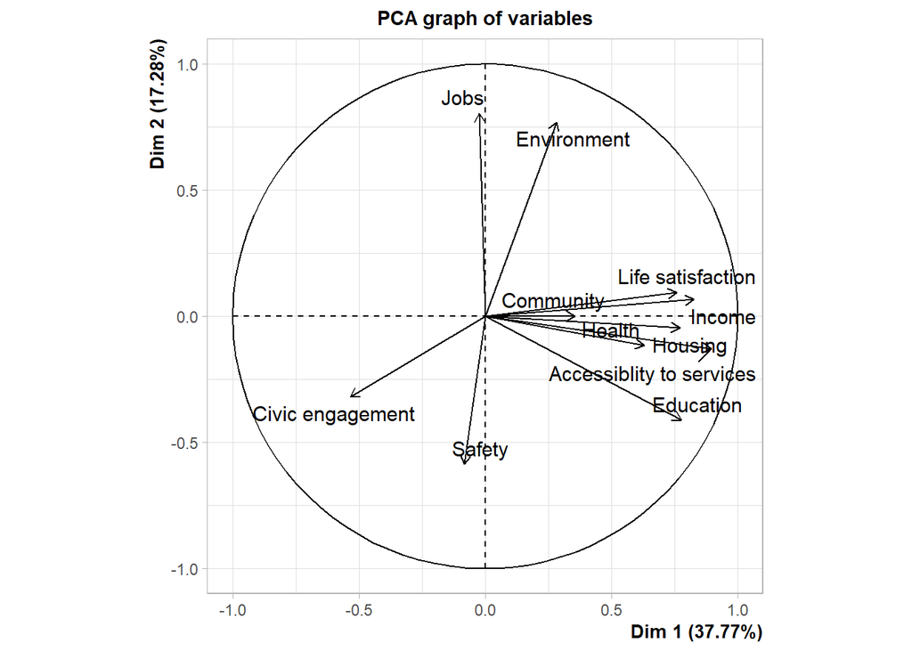

```r
#Checking the results
print(mexico_pca)
```

```
## **Results for the Principal Component Analysis (PCA)**
## The analysis was performed on 32 individuals, described by 11 variables
## *The results are available in the following objects:
##
##    name               description
## 1  "$eig"             "eigenvalues"
## 2  "$var"             "results for the variables"
## 3  "$var$coord"       "coord. for the variables"
## 4  "$var$cor"         "correlations variables - dimensions"
## 5  "$var$cos2"        "cos2 for the variables"
## 6  "$var$contrib"     "contributions of the variables"
## 7  "$ind"             "results for the individuals"
## 8  "$ind$coord"       "coord. for the individuals"
## 9  "$ind$cos2"        "cos2 for the individuals"
## 10 "$ind$contrib"     "contributions of the individuals"
## 11 "$call"            "summary statistics"
## 12 "$call$centre"     "mean of the variables"
## 13 "$call$ecart.type" "standard error of the variables"
## 14 "$call$row.w"      "weights for the individuals"
## 15 "$call$col.w"      "weights for the variables"
```

#VISUALIZING THE PCA

#Scree Plot

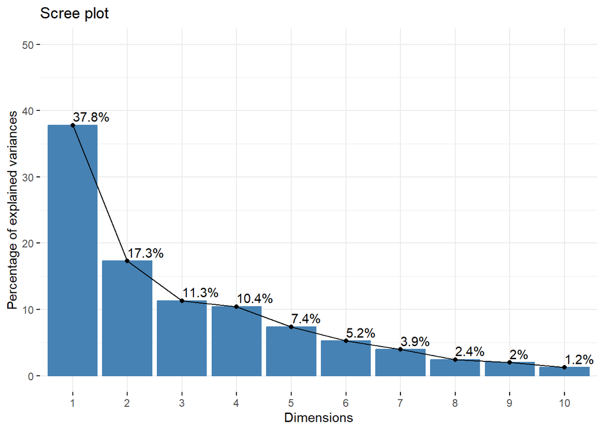

```r
#Visualizing the results with a scree plot (eigenvalues)
fviz_eig(mexico_pca, addlabels = TRUE, ylim = c(0, 50))
```

#Visualizing the Mexican Provinces on the first two principal component axes #We can plot the Mexican regions based on their principal component coordinates.

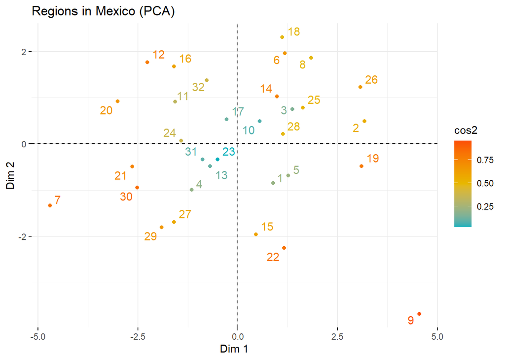

```r
#Visualize the individuals (regions) on the principal component axes
fviz_pca_ind(mexico_pca,
             col.ind = "cos2", #Color by the quality of representation
             gradient.cols = c("#00AFBB", "#E7B800", "#FC4E07"),
             repel = TRUE, #Avoid text overlapping
             title = "Regions in Mexico (PCA)",
             xlab = "Dim 1",
             ylab = "Dim 2")
```

#The scatter plot of the two principal components (Dim1 and Dim2) allows us to visualize the distribution of the data points. The scatter plot provides insight into the relationship between the original variables and the first two components and can help us understand the variability these two components explain. The position of the data points on the scatter plot allows us to identify any potential outliers or groups within the data. In the plot, each point represents a single region. It also shows the relationship between the provinces based on their scores/colours on the first two principal components. The areas being close to each other and having the same colours demonstrate similar well-being/development values.

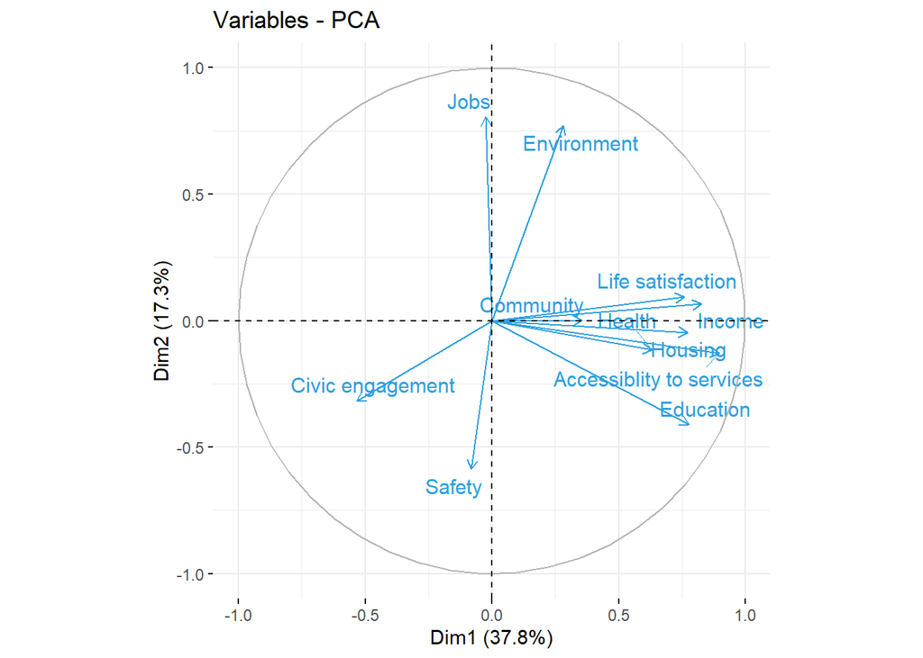

```r
#Visualizing the results with a Variables plot
fviz_pca_var(mexico_pca, col.var = "#2E9FDF", repel = TRUE)
```

#Comments on PCA and Visualizations #The Dim1 and Dim2 values show the principal components in the three different PCA plots. These two percentage values (Dim1 is 37.8% & Dim2 is 17.3%) demonstrate the variance values of the data explained by the two principal components.

#In other words, Dim1 is 37.8% meaning the first principal component explains 37.8% of the total variance in the dataset (the largest explaining variance). Besides, Dim2 is 17.3% indicating the second principal component explains 17.3% of the total variance (second largest explaining variance).

#Finally, these two values explain 55.1% or more than half of the total variance (37.8% + 17.3%).

#Based on the variables plot, we can say health, housing, community, income and life satisfaction are correlated.

```r
#Showing differently: let's sum the variances (Dim1 and Dim2 as two components).
variance_first_two_pca <- mexico_pca$eig[1, 2] + mexico_pca$eig[2, 2]

variance_first_two_pca #55.1%
```

```
## [1] 55.05064
```

#7. CLUSTERING WITH K-MEANS

#Clustering is an unsupervised machine learning technique to group comparable data based on their features. The K-means clustering method splits the data into specified groups. In this section, we will attempt to identify distinct groups of regions with comparable elements in order to design policies and implement policy interventions.

#K-means Clustering

#In this section, we will apply k-means clustering to group comparable data and we will use the first two principal components as features to cluster the observations.

```r
#Let's set the seed to 1234 for reproducibility
set.seed(1234)

#A few lines of the data
head(mexico_pca$ind$coord)
```

```
##        Dim.1      Dim.2       Dim.3      Dim.4      Dim.5
## 1  0.8843723 -0.8455517  0.56405897 -2.0747692 -0.4525334
## 2  3.1740636  0.4874337 -1.30077873  1.9074663  0.7964506
## 3  1.3672198  0.7442913  1.01466887 -2.8569479 -0.5082131
## 4 -1.1565213 -0.9913798  2.08378097  1.8919028 -0.5558714
## 5  1.2669947 -0.6824698  0.80701916 -1.5485495  1.7977894
## 6  1.1840537  1.9538596 -0.04561048  0.2284943  0.9121276
```

#PCA Scores and Dimensions

```r
#Extracting the PCA scores
pca_scores <- mexico_pca$var$coord

#Displaying the PCA scores for Dim1 and Dim2
mexican_pca1_pca2 <- pca_scores[, c(1, 2)]
mexican_pca1_pca2
```

```
##                                Dim.1        Dim.2
## Education                 0.77743677 -0.411114850
## Jobs                     -0.02383758  0.804987080
## Income                    0.82613049  0.066518282
## Safety                   -0.08262809 -0.586703993
## Health                    0.63045628 -0.116204959
## Environment               0.28268994  0.770069248
## Civic engagement         -0.53413336 -0.318220923
## Accessiblity to services  0.89584237 -0.128813074
## Housing                   0.77135944 -0.046674606
## Community                 0.35514933  0.001251356
## Life satisfaction         0.75742797  0.094962594
```

##The result tells us excluding jobs, safety and civic engagement, all other components contribute positively to the Dimension 1. This implies that Dimension 1 could be seen as a measure of overall development, given higher scores in this dimension are typically associated with better socioeconomic conditions.

#Intermediate data frame

```r
#Let's set the seed to 1234 for reproducibility
set.seed(1234)

#Creating an intermediate data frame (including PCA1 and PCA2)
mexico_comps <- tibble(pca_1 = mexico_pca$ind$coord[ ,1],
                          pca_2 = mexico_pca$ind$coord[ ,2]
                       )
```

#Visualizing the Clusters

#Following the clustering for each Mexican province, it’d be useful to plot the regions according to their principal components’ coordinates, and colour them by the clusters.

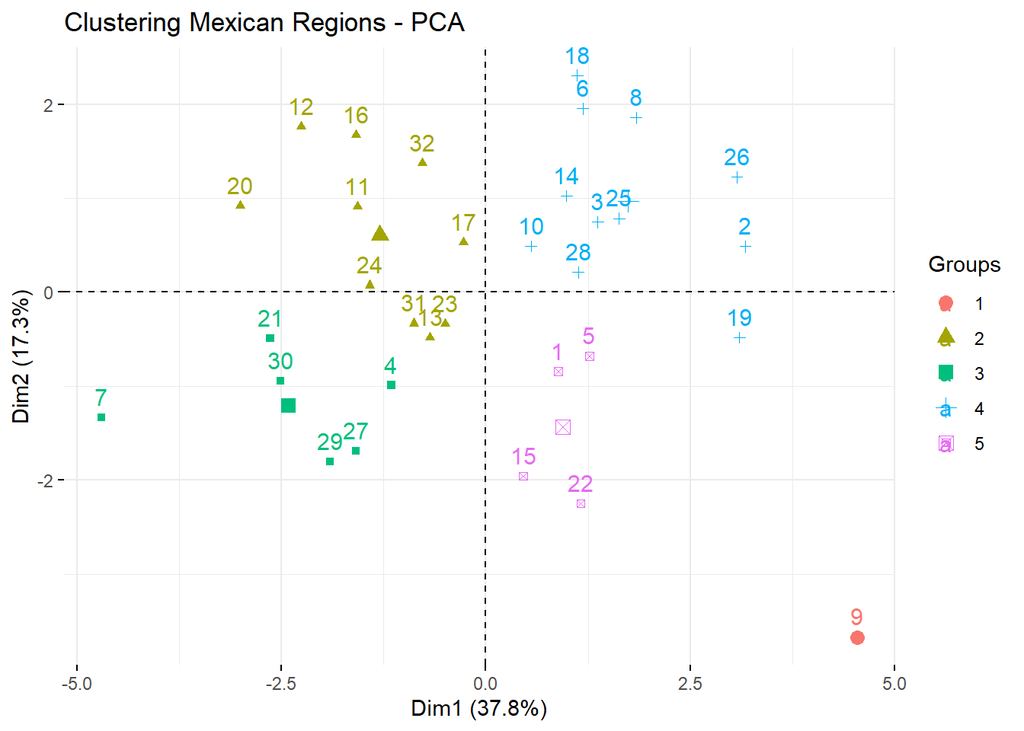

```r
#Assigning development scores to a new matrix
dev_matrix <- as.matrix(mexico_data$development_model)

#Setting seed for reproducibility
set.seed(1234)

#Applying k-means clustering on development scores ==> 5 Clusters
mexico_km <- kmeans(mexico_comps, centers = 5, nstart = 20, iter.max = 50)

#Converting assigned clusters to factor
dev_clusters_as_factor <- factor(mexico_km$cluster)

#Adding the 'cluster' column to the Mexican data
mexico_data_with_wb_clusters <- mexico_data %>%
  mutate(dev_cluster = dev_clusters_as_factor)

#Regions colored by cluster
fviz_pca_ind(mexico_pca,
             title = "Clustering Mexican Regions - PCA",
             habillage = dev_clusters_as_factor)
```

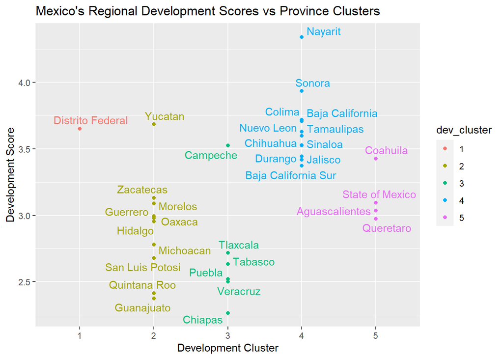

```r
#Making a scatterplot of development scores vs. cluster, coloured by cluster
ggplot(mexico_data_with_wb_clusters, aes(y = development_model, x = dev_cluster, color = dev_cluster)) +
  geom_point() +
  geom_text_repel(aes(label = Provinces), show.legend = FALSE) +
  labs(x = "Development Cluster", y = "Development Score") +
  ggtitle("Mexico's Regional Development Scores vs Province Clusters")
```

#8. DISCUSSION AND RESULTS

#According to the results of the PCA analysis and K-Means Clustering, there are 5 clusters having different development scoreas and weighted values. There are mainly 5 clusters listed below:

#Cluster 1: Distrito Federal #Cluster 2: Guanajuato, Quintana Roo, Hidalgo, Michoacan, Morelos, Oaxaca, Zacatecas, Guerrero, San Luis Potosi, Yucatan #Cluster 3: Tabasco, Puebla, Veracruz, Chiapas, Campeche, Tlaxcala #Cluster 4: Baja California, Durango, Sonora, Chihuahua, Jalisco, Sinaloa, Baja California Sur, Nuevo Leon, Tamaulipas, Nayarit, Colima #Cluster 5: State of Mexico, Aguascalientes, Queretaro, Coahuila

#Key Insights

#Cluster 1, which solely includes the Distrito Federal, demonstrates distinct development features. This region stands apart from the rest of Mexico, suggesting that the Distrito Federal may experience higher levels of socio-economic growth compared to other regions.

#Cluster 4 enjoys high education, income, health, environment, housing and life satisfaction rates while it needs an intervention in safety and civic engagement.

#Finally, Cluster 5, exhibiting relatively small absolute values in both dimensions, can be considered a cluster with average or mixed development levels. For these regions, pinpointing specific areas of improvement and devising tailored policies to tackle their unique development challenges is of utmost importance.

#In summary, recognizing the distinct development characteristics of each cluster will enable policymakers to devise more effective strategies and allocate resources more efficiently to cater to the specific requirements of each area.

#It is also clear that the most members of the Cluster 3 have big populations (Please see the ‘population’ section), and policymakers should consider their population and population density while developing policies. Besides, based on income levels, Cluster 3 also has regions having low income levels (Please see the ‘population’ section)

#For future use, we can assign new names for clusters to make regional decisions to alleviate poverty and better address regional disparities, as seen below: #Cluster 1 = MXC1, Cluster 2 = MXC2, Cluster 3 = MXC3, Cluster 4 = MXC4, Cluster 5 = MXC5

#Long story short, MXC2 and MXC3 are the first two regional development group/cluster to focus on the policymakers based on the OECD regional economic, social and well-being data.

#REFERENCES

#Global Data Lab (2023) Subnational Human Development Index, Mexico, Available at: https://globaldatalab.org/shdi/table/shdi/MEX/?levels=1+4&years=2021&interpolation=0&extrapolation=0

#OECD (2018) OECD Regional Well-Being: A user’s guide, Available at: https://www.oecdregionalwellbeing.org///assets/downloads/Regional-Well-Being-User-Guide.pdf